# Week 2 Session 1

## Welcome to Week 2

Recap what we learned from Week 1

## Intro to Statistics

Before we start, we need to mention that Statistics is divided mainly into two parts.

- Descriptive Statistics (*Course Focuse*)
  - This branch focuses on describing the Data with out making and conclusions
- Inferential Statistics
  - This branch is all about making conclusions. It takes sample from the population and try to make statistical tests to generalize the idea.

## Types of data

In order to be able to describe the data we need to know their types first.

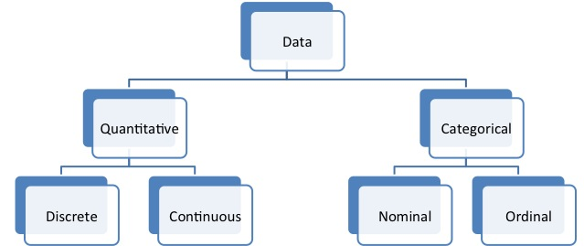

## Catagorical Data

In many cases especially in classificaiton peroblem this is usually our target variable.

We can describe categorical data by

- Counts
- Percentages

However, they are very useful in analytical taks such as

- Grouping
- Filtering

## Demo

M&M samples.

[figure not shown]

## Quantative Data

Those are excat variables and open doors for many statistical analysis.

We can describe quantative data by

- Measure of cerntrality
  - Mean
  - Median
  - Mode
- Measure of Variability
  - Range
  - Interquartile Range (IQR)
  - Standard Deviation
  - Variance

- Outliers

## Data Preprocessing

Why do we preprocess data?

- Fields that are obsolete or redundant
- Missing values
- Outliers
- Data in a form not suitable for the machine learning models;
- Values not consistent with policy or common sense.

## Common Tasks in Data preprocessing

- Data cleaning
- Handling Missing data
- Identify misclassificaitons
- Graphically identify outliers
- Transformation Data *to work better with ML models*
- Normalize The data